# Devoir A2022

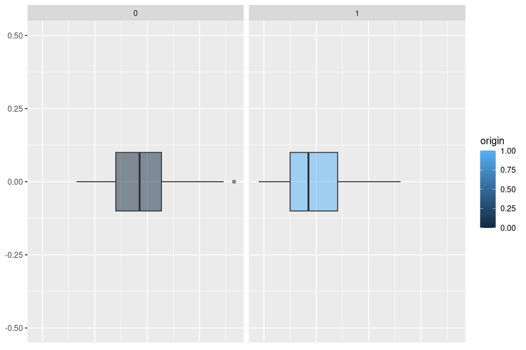

```r
mondata%>%
  ggplot(aes(x=mpg, fill=origin)) +
  geom_boxplot(
    alpha = 0.5,
    width = 0.2
  ) +
  facet_wrap(
    ~origin, nrow=1
  )+
  ylim(-0.5, 0.5) +
  labs(x='L’efficacité en carburant du véhicule') +
  theme(
    axis.title.x = element_blank(),
    axis.text.x = element_blank(),
    axis.ticks.x = element_blank()
)
```

• un tableau des statistiques descriptives par groupe : moyenne, quartiles, variance, écart type, intervalle de confiance pour la moyenne ;

```r
mondata%>%
  tbl_summary(
    include = mpg,
    by = origin,
    label = mpg ~ "mpg",
    type = mpg ~ "continuous2",
    statistic = mpg ~ c(
      "{mean}",
      "{var}",
      "{sd}",
      "{min}",
      "{max}",
      "{p25}",
      "{median}",
      "{p75}"
      )
    )-> mpg.stats.table

mpg.stats.table %>%
  add_stat_label(
    label = mpg ~ c(
      "Moyenne",
      "Variance",
      "Écart-type",
      "Minimum",
      "Maximum",
      "Premier quartile",
      "Médiane",
      "Troisième quartile"
    )
  ) -> mpg.stats.table

mpg.stats.table %>%
  modify_header(label ~ "**Statistiques descriptives**") %>%
  modify_header(all_stat_cols() ~ "*{level}*"
)-> mpg.stats.table

mpg.stats.table %>%
  bold_labels() %>%
  italicize_levels() -> mpg.stats.table

mpg.stats.table %>%
  add_ci()
```

| **Statistiques descriptives** | *0* | **95% CI**<sup>1</sup> | *1* | **95% CI**<sup>1</sup> |
| --- | --- | --- | --- | --- |
| mpg |  | 27, 30 |  | 19, 21 |
| Moyenne | 29 |  | 20 |  |
| Variance | 46 |  | 41 |  |
| Écart-type | 7 |  | 6 |  |
| Minimum | 16 |  | 9 |  |
| Maximum | 47 |  | 36 |  |
| Premier quartile | 24 |  | 15 |  |
| Médiane | 29 |  | 18 |  |
| Troisième quartile | 33 |  | 24 |  |

<sup>1</sup> CI = Confidence Interval

• un test d’hypothèses sur l’égalité des variances des deux groupes ;

```r
var.test(mpg ~ origin, data=mondata, alternative = "two.sided")
```

```
    F test to compare two variances

data:  mpg by origin
F = 1.1153, num df = 95, denom df = 123, p-value = 0.5667
alternative hypothesis: true ratio of variances is not equal to 1
95 percent confidence interval:
 0.7657915 1.6395772
sample estimates:
ratio of variances
           1.11526
```

• un test d’hypothèses sur l’égalité des moyennes des deux groupes.

```r
t.test(mpg ~ origin, data=mondata, alternative = "two.sided")
```

```
    Welch Two Sample t-test

data:  mpg by origin
t = 9.7929, df = 198.71, p-value < 2.2e-16
alternative hypothesis: true difference in means between group 0 and group 1 is not equal to 0
95 percent confidence interval:
  7.02920 10.57389
sample estimates:
mean in group 0 mean in group 1
       28.73542        19.93387
```

• (5 points) Effectuez l’ajustement (i.e. obtenir le tableau des coefficients de régression, le tableau d’analyse de la variance).

```r
Y <- mondata$mpg
X1 <- mondata$displacement
X2 <- mondata$weight
X3 <- mondata$origin

linModel1 <- lm(Y ~ X1)
summary(linModel1)
```

```
Call:
lm(formula = Y ~ X1)

Residuals:
     Min       1Q   Median       3Q      Max
-12.6978  -3.0598  -0.6526   2.3310  16.8728

Coefficients:
             Estimate Std. Error t value Pr(>|t|)
(Intercept) 34.944473   0.674347   51.82   <2e-16 ***
X1          -0.060666   0.003202  -18.94   <2e-16 ***
---
Signif. codes:  0 ‘***’ 0.001 ‘**’ 0.01 ‘*’ 0.05 ‘.’ 0.1 ‘ ’ 1

Residual standard error: 4.853 on 218 degrees of freedom
Multiple R-squared:  0.6221,    Adjusted R-squared:  0.6204
F-statistic: 358.9 on 1 and 218 DF,  p-value: < 2.2e-16
```

```r
linModel1$coefficients
```

```
(Intercept)          X1
34.94447336 -0.06066641
```

```r
anova(linModel1)
```

```
Analysis of Variance Table

Response: Y
           Df Sum Sq Mean Sq F value    Pr(>F)
X1          1 8453.2  8453.2  358.86 < 2.2e-16 ***
Residuals 218 5135.1    23.6
---
Signif. codes:  0 ‘***’ 0.001 ‘**’ 0.01 ‘*’ 0.05 ‘.’ 0.1 ‘ ’ 1
```

```r
linModel2 <- lm(Y ~ X1^2)
summary(linModel2)
```

```
Call:
lm(formula = Y ~ X1^2)

Residuals:
     Min       1Q   Median       3Q      Max
-12.6978  -3.0598  -0.6526   2.3310  16.8728

Coefficients:
             Estimate Std. Error t value Pr(>|t|)
(Intercept) 34.944473   0.674347   51.82   <2e-16 ***
X1          -0.060666   0.003202  -18.94   <2e-16 ***
---
Signif. codes:  0 ‘***’ 0.001 ‘**’ 0.01 ‘*’ 0.05 ‘.’ 0.1 ‘ ’ 1

Residual standard error: 4.853 on 218 degrees of freedom
Multiple R-squared:  0.6221,    Adjusted R-squared:  0.6204
F-statistic: 358.9 on 1 and 218 DF,  p-value: < 2.2e-16
```

```r
linModel2$coefficients
```

```
(Intercept)          X1
34.94447336 -0.06066641
```

```r
anova(linModel2)
```

```
Analysis of Variance Table

Response: Y
           Df Sum Sq Mean Sq F value    Pr(>F)
X1          1 8453.2  8453.2  358.86 < 2.2e-16 ***
Residuals 218 5135.1    23.6
---
Signif. codes:  0 ‘***’ 0.001 ‘**’ 0.01 ‘*’ 0.05 ‘.’ 0.1 ‘ ’ 1
```

```r
linModel3 <- lm(log(Y) ~log(X1) )
summary(linModel3)
```

```
Call:
lm(formula = log(Y) ~ log(X1))

Residuals:
     Min       1Q   Median       3Q      Max
-0.66556 -0.12026  0.00221  0.13383  0.59515

Coefficients:
            Estimate Std. Error t value Pr(>|t|)
(Intercept)  5.85295    0.11992   48.81   <2e-16 ***
log(X1)     -0.54067    0.02352  -22.98   <2e-16 ***
---
Signif. codes:  0 ‘***’ 0.001 ‘**’ 0.01 ‘*’ 0.05 ‘.’ 0.1 ‘ ’ 1

Residual standard error: 0.1861 on 218 degrees of freedom
Multiple R-squared:  0.7079,    Adjusted R-squared:  0.7065
F-statistic: 528.2 on 1 and 218 DF,  p-value: < 2.2e-16
```

```r
linModel3$coefficients
```

```
(Intercept)     log(X1)
  5.8529463  -0.5406658
```

```r
anova(linModel3)
```

```
Analysis of Variance Table

Response: log(Y)
           Df  Sum Sq Mean Sq F value    Pr(>F)
log(X1)     1 18.2947 18.2947  528.23 < 2.2e-16 ***
Residuals 218  7.5502  0.0346
---
Signif. codes:  0 ‘***’ 0.001 ‘**’ 0.01 ‘*’ 0.05 ‘.’ 0.1 ‘ ’ 1
```

```r
linModel4 <- lm(log(Y) ~X1)
summary(linModel4)
```

```
Call:
lm(formula = log(Y) ~ X1)

Residuals:
     Min       1Q   Median       3Q      Max
-0.57650 -0.11262 -0.01162  0.12735  0.63696

Coefficients:
              Estimate Std. Error t value Pr(>|t|)
(Intercept)  3.6313215  0.0258848  140.29   <2e-16 ***
X1          -0.0028211  0.0001229  -22.95   <2e-16 ***
---
Signif. codes:  0 ‘***’ 0.001 ‘**’ 0.01 ‘*’ 0.05 ‘.’ 0.1 ‘ ’ 1

Residual standard error: 0.1863 on 218 degrees of freedom
Multiple R-squared:  0.7073,    Adjusted R-squared:  0.7059
F-statistic: 526.7 on 1 and 218 DF,  p-value: < 2.2e-16
```

```r
linModel4$coefficients
```

```
 (Intercept)           X1
 3.631321505 -0.002821058
```

```r
anova(linModel4)
```

```
Analysis of Variance Table

Response: log(Y)
           Df  Sum Sq Mean Sq F value    Pr(>F)
X1          1 18.2788 18.2788  526.66 < 2.2e-16 ***
Residuals 218  7.5661  0.0347
---
Signif. codes:  0 ‘***’ 0.001 ‘**’ 0.01 ‘*’ 0.05 ‘.’ 0.1 ‘ ’ 1
```

```r
linModel5 <- lm(Y ~ X2)
summary(linModel5)
```

```
Call:
lm(formula = Y ~ X2)

Residuals:
     Min       1Q   Median       3Q      Max
-11.8378  -2.9317  -0.4811   2.3942  16.6554

Coefficients:
              Estimate Std. Error t value Pr(>|t|)
(Intercept) 46.0413411  1.0796593   42.64   <2e-16 ***
X2          -0.0076288  0.0003552  -21.48   <2e-16 ***
---
Signif. codes:  0 ‘***’ 0.001 ‘**’ 0.01 ‘*’ 0.05 ‘.’ 0.1 ‘ ’ 1

Residual standard error: 4.472 on 218 degrees of freedom
Multiple R-squared:  0.6791,    Adjusted R-squared:  0.6776
F-statistic: 461.3 on 1 and 218 DF,  p-value: < 2.2e-16
```

```r
linModel5$coefficients
```

```
 (Intercept)           X2
46.041341096 -0.007628798
```

```r
anova(linModel5)
```

```
Analysis of Variance Table

Response: Y
           Df Sum Sq Mean Sq F value    Pr(>F)
X2          1 9227.7  9227.7  461.33 < 2.2e-16 ***
Residuals 218 4360.5    20.0
---
Signif. codes:  0 ‘***’ 0.001 ‘**’ 0.01 ‘*’ 0.05 ‘.’ 0.1 ‘ ’ 1
```

```r
linModel6 <- lm(Y ~ X2^2)
summary(linModel6)
```

```
Call:
lm(formula = Y ~ X2^2)

Residuals:
     Min       1Q   Median       3Q      Max
-11.8378  -2.9317  -0.4811   2.3942  16.6554

Coefficients:
              Estimate Std. Error t value Pr(>|t|)
(Intercept) 46.0413411  1.0796593   42.64   <2e-16 ***
X2          -0.0076288  0.0003552  -21.48   <2e-16 ***
---
Signif. codes:  0 ‘***’ 0.001 ‘**’ 0.01 ‘*’ 0.05 ‘.’ 0.1 ‘ ’ 1

Residual standard error: 4.472 on 218 degrees of freedom
Multiple R-squared:  0.6791,    Adjusted R-squared:  0.6776
F-statistic: 461.3 on 1 and 218 DF,  p-value: < 2.2e-16
```

```r
linModel6$coefficients
```

```
 (Intercept)           X2
46.041341096 -0.007628798
```

```r
anova(linModel6)
```

```
Analysis of Variance Table

Response: Y
           Df Sum Sq Mean Sq F value    Pr(>F)
X2          1 9227.7  9227.7  461.33 < 2.2e-16 ***
Residuals 218 4360.5    20.0
---
Signif. codes:  0 ‘***’ 0.001 ‘**’ 0.01 ‘*’ 0.05 ‘.’ 0.1 ‘ ’ 1
```

```r
linModel7 <- lm(log(mondata$mpg) ~ log(mondata$weight) )
summary(linModel7)
```

```
Call:
lm(formula = log(mondata$mpg) ~ log(mondata$weight))

Residuals:
     Min       1Q   Median       3Q      Max
-0.51720 -0.10534 -0.00395  0.09967  0.47163

Coefficients:
                    Estimate Std. Error t value Pr(>|t|)
(Intercept)         11.56674    0.32020   36.12   <2e-16 ***
log(mondata$weight) -1.06502    0.04031  -26.42   <2e-16 ***
---
Signif. codes:  0 ‘***’ 0.001 ‘**’ 0.01 ‘*’ 0.05 ‘.’ 0.1 ‘ ’ 1

Residual standard error: 0.168 on 218 degrees of freedom
Multiple R-squared:  0.762, Adjusted R-squared:  0.7609
F-statistic: 698.1 on 1 and 218 DF,  p-value: < 2.2e-16
```

```r
linModel7$coefficients
```

```
        (Intercept) log(mondata$weight)
          11.566735           -1.065018
```

```r
anova(linModel7)
```

```
Analysis of Variance Table

Response: log(mondata$mpg)
                     Df  Sum Sq Mean Sq F value    Pr(>F)
log(mondata$weight)   1 19.6947 19.6947   698.1 < 2.2e-16 ***
Residuals           218  6.1502  0.0282
---
Signif. codes:  0 ‘***’ 0.001 ‘**’ 0.01 ‘*’ 0.05 ‘.’ 0.1 ‘ ’ 1
```

```r
linModel8 <- lm(log(Y) ~ X2)
summary(linModel8)
```

```
Call:
lm(formula = log(Y) ~ X2)

Residuals:
     Min       1Q   Median       3Q      Max
-0.50237 -0.10633 -0.00992  0.09648  0.45388

Coefficients:
              Estimate Std. Error t value Pr(>|t|)
(Intercept)  4.143e+00  4.021e-02  103.05   <2e-16 ***
X2          -3.533e-04  1.323e-05  -26.71   <2e-16 ***
---
Signif. codes:  0 ‘***’ 0.001 ‘**’ 0.01 ‘*’ 0.05 ‘.’ 0.1 ‘ ’ 1

Residual standard error: 0.1666 on 218 degrees of freedom
Multiple R-squared:  0.766, Adjusted R-squared:  0.7649
F-statistic: 713.6 on 1 and 218 DF,  p-value: < 2.2e-16
```

```r
linModel8$coefficients
```

```
  (Intercept)            X2
 4.1432714372 -0.0003533544
```

```r
anova(linModel8)
```

```
Analysis of Variance Table

Response: log(Y)
           Df  Sum Sq Mean Sq F value    Pr(>F)
X2          1 19.7972 19.7972  713.63 < 2.2e-16 ***
Residuals 218  6.0477  0.0277
---
Signif. codes:  0 ‘***’ 0.001 ‘**’ 0.01 ‘*’ 0.05 ‘.’ 0.1 ‘ ’ 1
```

• (5 points) Tester la signification du modèle et effectuez une analyse des résidus (normalité, homoscédasticité, points atypiques, etc.)

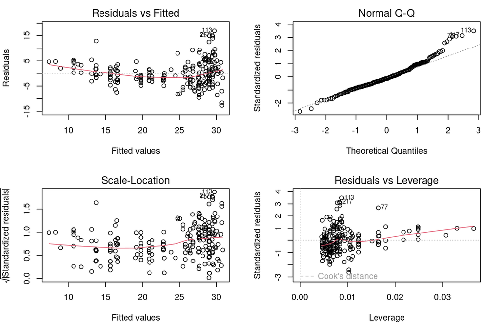

```r
par(mfrow = c(2,2))
plot(linModel1)
```

```r
shapiro.test(rstudent(linModel1))
```

```
    Shapiro-Wilk normality test

data:  rstudent(linModel1)
W = 0.96332, p-value = 1.878e-05
```

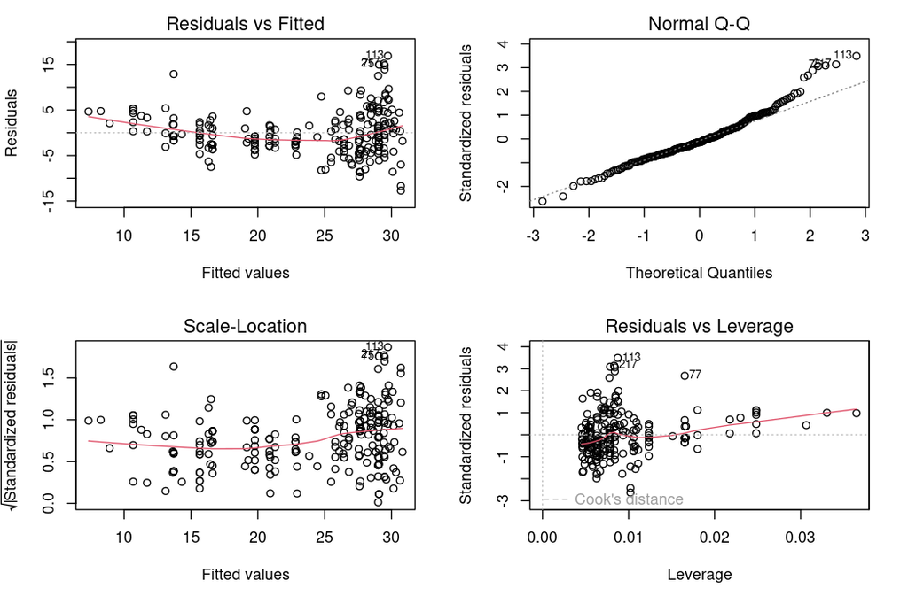

```r
par(mfrow = c(2,2))
plot(linModel2)
```

```r
shapiro.test(rstudent(linModel2))
```

```
    Shapiro-Wilk normality test

data:  rstudent(linModel2)
W = 0.96332, p-value = 1.878e-05
```

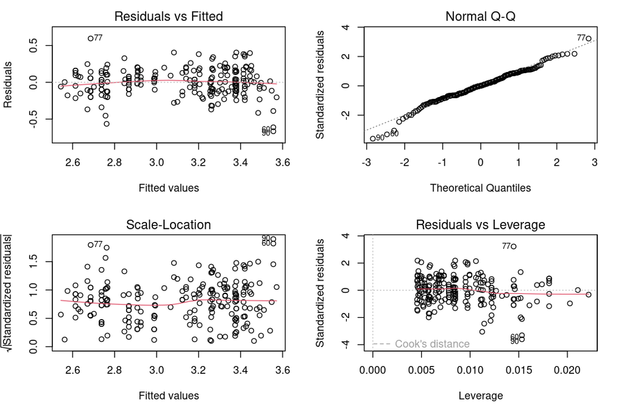

```r
par(mfrow = c(2,2))
plot(linModel3)
```

```r
shapiro.test(rstudent(linModel3))
```

```
    Shapiro-Wilk normality test

data:  rstudent(linModel3)
W = 0.98211, p-value = 0.006909
```

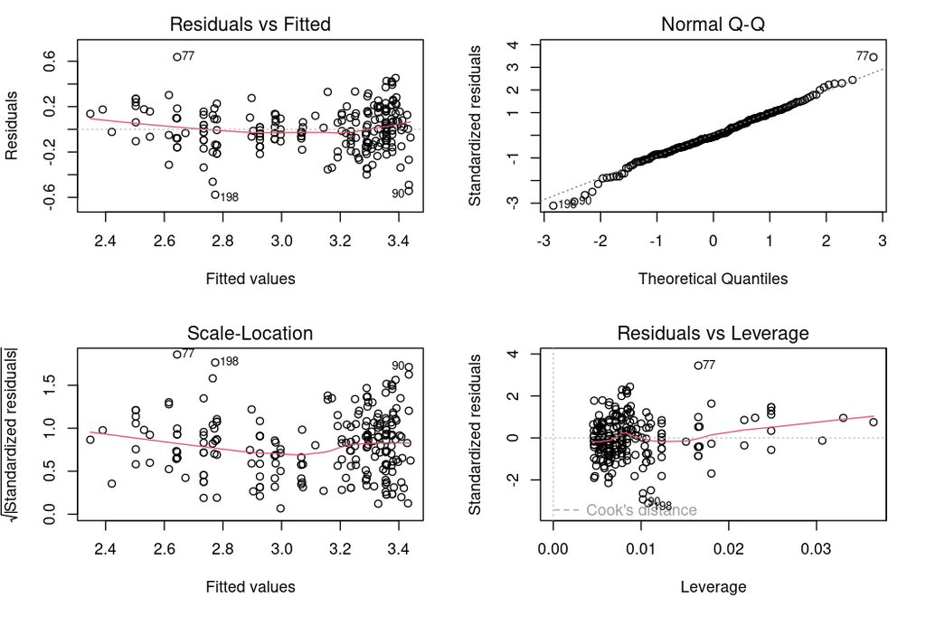

```r
par(mfrow = c(2,2))
plot(linModel4)
```

```r
shapiro.test(rstudent(linModel4))
```

```
    Shapiro-Wilk normality test

data:  rstudent(linModel4)
W = 0.99109, p-value = 0.1977
```

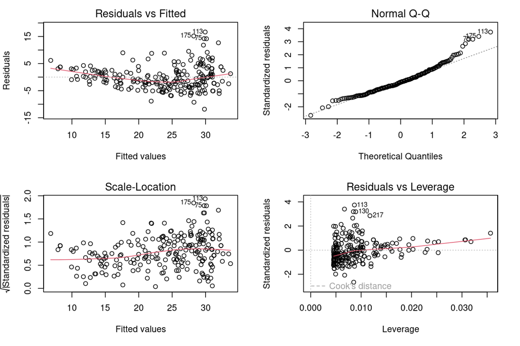

```r
par(mfrow = c(2,2))
plot(linModel5)
```

```r
shapiro.test(rstudent(linModel5))
```

```
    Shapiro-Wilk normality test

data:  rstudent(linModel5)
W = 0.9526, p-value = 1.213e-06
```

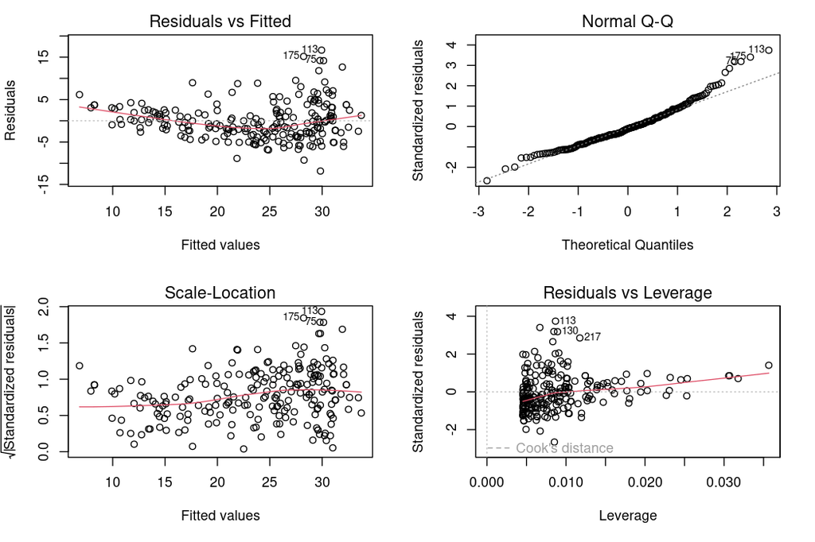

```r
par(mfrow = c(2,2))
plot(linModel6)
```

```r
shapiro.test(rstudent(linModel6))
```

```
    Shapiro-Wilk normality test

data:  rstudent(linModel6)
W = 0.9526, p-value = 1.213e-06
```

```r
par(mfrow = c(2,2))
plot(linModel7)
shapiro.test(residuals(linModel7))
```

[output not shown]

```r
par(mfrow = c(2,2))
plot(linModel8)
shapiro.test(residuals(linModel8))
```

[output not shown]

• (3 points) Donner un intervalle de confiance pour chacun des paramètres β0 et β1 des modèles 1 et 5.

```r
confint(linModel1)
```

[output not shown]

```r
confint(linModel5)
```

[output not shown]

• (2 points) En conclusion : effectuez une comparaison

5. (5 points) Sur la base du meilleur modèle que vous avez obtenu en d), calculez un intervalle de prévision pour l’efficacité en carburant d’un véhicule ayant les caractéristiques suivantes : X1 = 190; X2 = 2500. Commentez brièvement votre résultat. Remarque. Notez que le modèle que vous avez obtenu en d) n’utilise pas nécessairement toutes les valeurs ci-dessus

```r
predict(linModel8, newdata = data.frame(X1 = 190, X2 = 2500), interval = "predict", level = 0.95)
```

[output not shown]